# Classify different data sets

### Basic includes

```python
# Using pandas to load the csv file
import pandas as pd

import numpy as np
import matplotlib.pyplot as plt

from keras import models
from keras import layers
from keras import callbacks
from keras.utils import to_categorical

# reuters and fashin mnist data set from keras
from keras.datasets import reuters
from keras.datasets import fashion_mnist

# needed to preprocess text
from keras.preprocessing.text import Tokenizer
```

### Classify the Fashion Mnist

```
(60000, 28, 28)
```

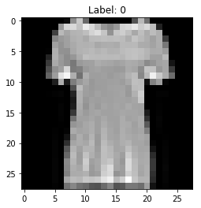

```python
(fashion_train_data, fashion_train_labels), (fashion_test_data, fashion_test_labels) = fashion_mnist.load_data()

print(fashion_train_data.shape)

test_index = 10

plt.title("Label: " + str(fashion_train_labels[test_index]))
plt.imshow(fashion_train_data[test_index], cmap="gray")
```

#### TO DO: Preprocess the data

1. Normalize the input data set
2. Perform one hot encoding
3. Create a train, test, and validation set

```python
# Normalize the input data set

# flatten arrays
fashion_train_data = fashion_train_data.reshape((60000, 28 * 28))
# turn values from 0-255 to 0-1
fashion_train_data = fashion_train_data.astype('float32') / 255

# Standardization for the test images
fashion_test_data = fashion_test_data.reshape((10000, 28 * 28))
fashion_test_data = fashion_test_data.astype('float32') / 255

# Perform one hot encoding
fashion_train_labels = to_categorical(fashion_train_labels)
fashion_test_labels = to_categorical(fashion_test_labels)

print(fashion_train_labels.shape)
print(fashion_test_labels.shape)

# Creating a validation set with the first 10000
validation_data = fashion_train_data[:10000]
validation_labels = fashion_train_labels[:10000]

x_data = fashion_train_data[10000:]
y_data = fashion_train_labels[10000:]

print(x_data.shape)
print(y_data.shape)
```

```
(60000, 10)
(10000, 10)
(50000, 784)
(50000, 10)
```

#### TO DO: Define and train a network, then plot the accuracy of the training, validation, and testing

1. Use a validation set
2. Propose and train a network
3. Print the history of the training
4. Evaluate with a test set

```python
# Building the model architecture
network = models.Sequential()
network.add(layers.Dense(128, activation='relu', input_shape= (28 * 28,)))
network.add(layers.Dropout(0.3))
network.add(layers.Dense(64, activation='relu'))
network.add(layers.Dropout(0.3))
network.add(layers.Dense(10, activation='softmax'))

network.summary()

early_stop = callbacks.EarlyStopping(monitor='val_loss', patience=2)
network.compile(loss='categorical_crossentropy', optimizer='adam', metrics=['accuracy'])
```

```
_________________________________________________________________
Layer (type)                 Output Shape              Param #
=================================================================
dense_91 (Dense)             (None, 128)               100480
_________________________________________________________________
dropout_64 (Dropout)         (None, 128)               0
_________________________________________________________________
dense_92 (Dense)             (None, 64)                8256
_________________________________________________________________
dropout_65 (Dropout)         (None, 64)                0
_________________________________________________________________
dense_93 (Dense)             (None, 10)                650
=================================================================
Total params: 109,386
Trainable params: 109,386
Non-trainable params: 0
_________________________________________________________________
```

```python
# Network Training
history = network.fit(x_data, y_data, epochs=25, validation_data = (validation_data, validation_labels), callbacks=[early_stop], verbose=2)
```

```
Train on 50000 samples, validate on 10000 samples
 - 5s - loss: 0.6531 - acc: 0.7641 - val_loss: 0.4254 - val_acc: 0.8458
 - 4s - loss: 0.4727 - acc: 0.8304 - val_loss: 0.3934 - val_acc: 0.8564
 - 4s - loss: 0.4392 - acc: 0.8428 - val_loss: 0.3648 - val_acc: 0.8714
 - 4s - loss: 0.4140 - acc: 0.8507 - val_loss: 0.3635 - val_acc: 0.8680
 - 4s - loss: 0.3980 - acc: 0.8563 - val_loss: 0.3558 - val_acc: 0.8721
 - 4s - loss: 0.3851 - acc: 0.8607 - val_loss: 0.3356 - val_acc: 0.8739
 - 4s - loss: 0.3705 - acc: 0.8662 - val_loss: 0.3350 - val_acc: 0.8775
 - 4s - loss: 0.3633 - acc: 0.8675 - val_loss: 0.3360 - val_acc: 0.8783
 - 4s - loss: 0.3548 - acc: 0.8705 - val_loss: 0.3300 - val_acc: 0.8784
 - 4s - loss: 0.3497 - acc: 0.8725 - val_loss: 0.3163 - val_acc: 0.8854
 - 4s - loss: 0.3393 - acc: 0.8749 - val_loss: 0.3136 - val_acc: 0.8846
 - 4s - loss: 0.3367 - acc: 0.8779 - val_loss: 0.3198 - val_acc: 0.8841
 - 4s - loss: 0.3327 - acc: 0.8787 - val_loss: 0.3132 - val_acc: 0.8881
 - 4s - loss: 0.3264 - acc: 0.8796 - val_loss: 0.3204 - val_acc: 0.8824
 - 4s - loss: 0.3228 - acc: 0.8816 - val_loss: 0.3123 - val_acc: 0.8845
 - 4s - loss: 0.3198 - acc: 0.8827 - val_loss: 0.3193 - val_acc: 0.8807
 - 4s - loss: 0.3167 - acc: 0.8849 - val_loss: 0.3162 - val_acc: 0.8829
```

```python
# Network Evaluation
test_loss, test_acc = network.evaluate(fashion_test_data, fashion_test_labels)

print("test loss: ", test_loss, "test accuracy: ", test_acc)
```

```
test loss:  0.34576726810932157 test accuracy:  0.878
```

```python
history_dict = history.history
acc = history_dict['acc']
val_acc = history_dict['val_acc']
loss = history_dict['loss']
val_loss = history_dict['val_loss']

epochs = range(1, len(acc) + 1)
```

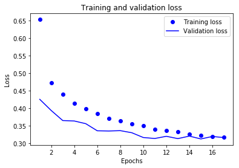

```python
# Plot of the validation and training loss

# "bo" is for "blue dot"
plt.plot(epochs, loss, 'bo', label='Training loss')
# b is for "solid blue line"
plt.plot(epochs, val_loss, 'b', label='Validation loss')
plt.title('Training and validation loss')
plt.xlabel('Epochs')
plt.ylabel('Loss')
plt.legend()

plt.show()
```

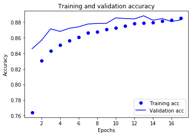

```python
# Plot of the validation and train accuracy

plt.clf()   # clear figure

plt.plot(epochs, acc, 'bo', label='Training acc')
plt.plot(epochs, val_acc, 'b', label='Validation acc')
plt.title('Training and validation accuracy')
plt.xlabel('Epochs')
plt.ylabel('Accuracy')
plt.legend()

plt.show()
```

#### Process followed to design and improve the model

The process I followed to improve and design the model was:

1. Followed the processes that we reviewed in class of the example 3 and 4 of Keras
2. Use similar normalization of data used for images
3. Defined a similar model of network with 3 layers and 2 dropouts (using relu and softmax for activation)
4. Defined adam to be the optimizer as that was the recommendation in class
5. Tried different combinations of epochs, neurons and layers until the accuracy overcomed 85%

## Classifying newswires

Build a network to classify Reuters newswires into 46 different mutually-exclusive topics.

### Load and review the data

```python
(reuters_train_data, reuters_train_labels), (reuters_test_data, reuters_test_labels) = reuters.load_data(num_words=10000)

print(reuters_train_data.shape)
print(reuters_train_labels.shape)
print(reuters_train_data[0])
print(reuters_train_labels[0])

print(set(reuters_train_labels))
```

```
(8982,)
(8982,)
[1, 2, 2, 8, 43, 10, 447, 5, 25, 207, 270, 5, 3095, 111, 16, 369, 186, 90, 67, 7, 89, 5, 19, 102, 6, 19, 124, 15, 90, 67, 84, 22, 482, 26, 7, 48, 4, 49, 8, 864, 39, 209, 154, 6, 151, 6, 83, 11, 15, 22, 155, 11, 15, 7, 48, 9, 4579, 1005, 504, 6, 258, 6, 272, 11, 15, 22, 134, 44, 11, 15, 16, 8, 197, 1…
3
{0, 1, 2, 3, 4, 5, 6, 7, 8, 9, 10, 11, 12, 13, 14, 15, 16, 17, 18, 19, 20, 21, 22, 23, 24, 25, 26, 27, 28, 29, 30, 31, 32, 33, 34, 35, 36, 37, 38, 39, 40, 41, 42, 43, 44, 45}
```

Load the word index to decode the train data.

```python
word_index = reuters.get_word_index()

reverse_index = dict([(value+3, key) for (key, value) in word_index.items()])

reverse_index[0] = "<PAD>"
reverse_index[1] = "<START>"
reverse_index[2] = "<UNKNOWN>"  # unknown
reverse_index[3] = "<UNUSED>"

decoded_review = ' '.join([reverse_index.get(i,'?') for i in reuters_train_data[0]])

print(decoded_review)
```

```
<START> <UNKNOWN> <UNKNOWN> said as a result of its december acquisition of space co it expects earnings per share in 1987 of 1 15 to 1 30 dlrs per share up from 70 cts in 1986 the company said pretax net should rise to nine to 10 mln dlrs from six mln dlrs in 1986 and rental operation revenues to 1…
```

#### TO DO: Preprocess the data

1. Normalize the input data set
2. Perform one hot encoding
3. Create a train, test, and validation set

```python
# Normalize the input data
tokenizer = Tokenizer(num_words=8982)
train_data_token = tokenizer.sequences_to_matrix(reuters_train_data, mode='binary')
test_data_token = tokenizer.sequences_to_matrix(reuters_test_data, mode='binary')

print(train_data_token.shape)
print(test_data_token.shape)

# Perform one-hot-encoding
one_hot_train_labels = to_categorical(reuters_train_labels)
one_hot_test_labels = to_categorical(reuters_test_labels)

print(one_hot_train_labels.shape)
print(one_hot_test_labels.shape)

# Create a train, test and validation set

# validation set
validation_data = train_data_token[:1000]
validation_labels = one_hot_train_labels[:1000]

x_data = train_data_token[1000:]
y_data = one_hot_train_labels[1000:]

print(x_data.shape)
print(y_data.shape)
```

```
(8982, 8982)
(2246, 8982)
(8982, 46)
(2246, 46)
(7982, 8982)
(7982, 46)
```

#### TO DO: Define and train a network, then plot the accuracy of the training, validation, and testing

1. Use a validation set
2. Propose and train a network
3. Print the history of the training
4. Evaluate with a test set

```python
# Building the model architecture

network = models.Sequential()
network.add(layers.Dense(92, activation='relu', input_shape= (8982,)))
network.add(layers.Dropout(0.3))
network.add(layers.Dense(46, activation='softmax'))
network.add(layers.Dropout(0.2))
network.summary()

early_stop = callbacks.EarlyStopping(monitor='val_loss', patience=6)
network.compile(loss='categorical_crossentropy', optimizer='adam', metrics=['accuracy'])
```

```
_________________________________________________________________
Layer (type)                 Output Shape              Param #
=================================================================
dense_94 (Dense)             (None, 92)                826436
_________________________________________________________________
dropout_66 (Dropout)         (None, 92)                0
_________________________________________________________________
dense_95 (Dense)             (None, 46)                4278
_________________________________________________________________
dropout_67 (Dropout)         (None, 46)                0
=================================================================
Total params: 830,714
Trainable params: 830,714
Non-trainable params: 0
_________________________________________________________________
```

```python
# Network Training
history = network.fit(x_data, y_data, epochs=15, validation_data = (validation_data, validation_labels), callbacks=[early_stop], verbose=2)
```

```
Train on 7982 samples, validate on 1000 samples
 - 5s - loss: 4.3051 - acc: 0.5443 - val_loss: 1.0436 - val_acc: 0.7650
 - 4s - loss: 3.7484 - acc: 0.6766 - val_loss: 0.8489 - val_acc: 0.8260
 - 4s - loss: 3.5623 - acc: 0.7223 - val_loss: 0.7699 - val_acc: 0.8240
 - 3s - loss: 3.5960 - acc: 0.7392 - val_loss: 0.7855 - val_acc: 0.8190
 - 4s - loss: 3.4542 - acc: 0.7506 - val_loss: 0.7880 - val_acc: 0.8300
 - 4s - loss: 3.4655 - acc: 0.7582 - val_loss: 0.7906 - val_acc: 0.8240
 - 4s - loss: 3.4136 - acc: 0.7637 - val_loss: 0.8180 - val_acc: 0.8290
 - 4s - loss: 3.3988 - acc: 0.7667 - val_loss: 0.8458 - val_acc: 0.8180
 - 4s - loss: 3.4021 - acc: 0.7642 - val_loss: 0.8588 - val_acc: 0.8180
```

```python
# Network evaluation

test_loss, test_acc = network.evaluate(test_data_token, one_hot_test_labels)

print("test loss: ", test_loss, "test accuracy: ", test_acc)
```

```
test loss:  0.9743016037894272 test accuracy:  0.799198575297956
```

```python
history_dict = history.history
acc = history_dict['acc']
val_acc = history_dict['val_acc']
loss = history_dict['loss']
val_loss = history_dict['val_loss']

epochs = range(1, len(acc) + 1)
```

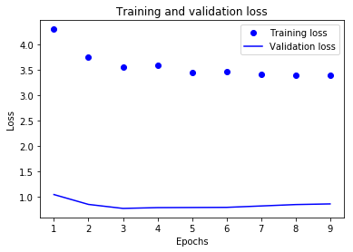

```python
# Plot of the validation and training loss

# "bo" is for "blue dot"
plt.plot(epochs, loss, 'bo', label='Training loss')
# b is for "solid blue line"
plt.plot(epochs, val_loss, 'b', label='Validation loss')
plt.title('Training and validation loss')
plt.xlabel('Epochs')
plt.ylabel('Loss')
plt.legend()

plt.show()
```

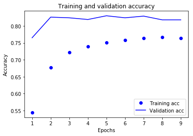

```python
# Plot of the validation and train accuracy

plt.clf()   # clear figure

plt.plot(epochs, acc, 'bo', label='Training acc')
plt.plot(epochs, val_acc, 'b', label='Validation acc')
plt.title('Training and validation accuracy')
plt.xlabel('Epochs')
plt.ylabel('Accuracy')
plt.legend()

plt.show()
```

## Predicting Student Admissions

Predict student admissions based on three pieces of data:

- GRE Scores
- GPA Scores
- Class rank

### Load and visualize the data

```python
student_data = pd.read_csv("student_data.csv")
print(student_data)
```

```
     admit  gre   gpa  rank
0        0  380  3.61     3
1        1  660  3.67     3
2        1  800  4.00     1
3        1  640  3.19     4
4        0  520  2.93     4
5        1  760  3.00     2
6        1  560  2.98     1
7        0  400  3.08     2
8        1  540  3.39     3
9        0  700  3.92     2
10       0  800  4.00     4
11       0  440  3.22     1
12       1  760  4.00     1
13       0  700  3.08     2
```

[output cut: 49 more lines]

Plot of the GRE and the GPA from the data.

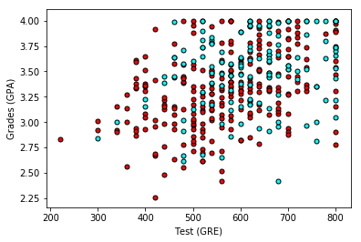

```python
X = np.array(student_data[["gre","gpa"]])
y = np.array(student_data["admit"])
admitted = X[np.argwhere(y==1)]
rejected = X[np.argwhere(y==0)]
plt.scatter([s[0][0] for s in rejected], [s[0][1] for s in rejected], s = 25, color = 'red', edgecolor = 'k')
plt.scatter([s[0][0] for s in admitted], [s[0][1] for s in admitted], s = 25, color = 'cyan', edgecolor = 'k')
plt.xlabel('Test (GRE)')
plt.ylabel('Grades (GPA)')

plt.show()
```

Plot of the data by class rank.

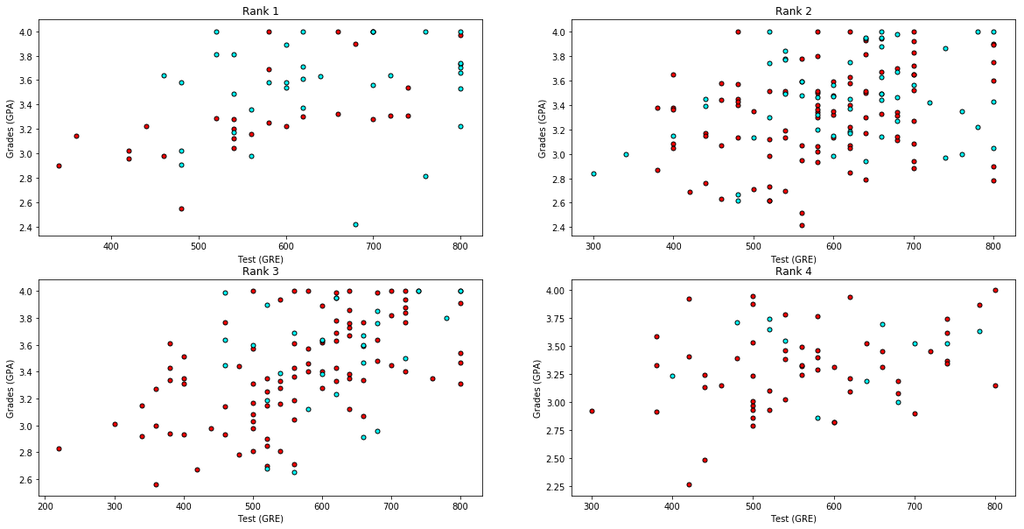

```python
f, plots = plt.subplots(2, 2, figsize=(20,10))
plots = [plot for sublist in plots for plot in sublist]

for idx, plot in enumerate(plots):
    data_rank = student_data[student_data["rank"]==idx+1]
    plot.set_title("Rank " + str(idx+1))
    X = np.array(data_rank[["gre","gpa"]])
    y = np.array(data_rank["admit"])
    admitted = X[np.argwhere(y==1)]
    rejected = X[np.argwhere(y==0)]
    plot.scatter([s[0][0] for s in rejected], [s[0][1] for s in rejected], s = 25, color = 'red', edgecolor = 'k')
    plot.scatter([s[0][0] for s in admitted], [s[0][1] for s in admitted], s = 25, color = 'cyan', edgecolor = 'k')
    plot.set_xlabel('Test (GRE)')
    plot.set_ylabel('Grades (GPA)')
```

#### TO DO: Preprocess the data

1. Normalize the input data set
2. Perform one hot encoding
3. Create a train, test, and validation set

```python
# Normalize the input data

mean_gre = np.average(student_data["gre"])
std_gre = np.std(student_data["gre"])

mean_gpa = np.average(student_data["gpa"])
std_gpa = np.std(student_data["gpa"])

one_hot_ranks = to_categorical(student_data["rank"] - 1)
print(one_hot_ranks.shape)

new_gre = ((student_data["gre"] - mean_gre) / std_gre)
new_gpa = ((student_data["gpa"] - mean_gpa) / std_gpa)

input_set = np.empty([len(student_data["gre"]),6])

input_set[:,0] = new_gre
input_set[:,1] = new_gpa
input_set[:,2:6] = one_hot_ranks

# Perform one-hot-encoding

one_hot_train_labels = to_categorical(student_data["admit"][:250])
one_hot_test_labels = to_categorical(student_data["admit"][250:])

print(one_hot_train_labels.shape)
print(one_hot_test_labels.shape)

# Create a train, test and validation set

train_data = input_set[:250]
test_data = input_set[250:]

validation_data = input_set[250:]
validation_labels = to_categorical(student_data["admit"][250:])

print(train_data.shape)
print(test_data.shape)
```

```
(400, 4)
(250, 2)
(150, 2)
(250, 6)
(150, 6)
```

#### TO DO: Define and train a network, then plot the accuracy of the training, validation, and testing

1. Use a validation set
2. Propose and train a network
3. Print the history of the training
4. Evaluate with a test set

```python
# Building the model architecture

network = models.Sequential()
network.add(layers.Dense(256, activation='relu', input_dim = 6))
network.add(layers.Dropout(0.4))
network.add(layers.Dense(32, activation='relu'))
network.add(layers.Dropout(0.2))
network.add(layers.Dense(2, activation='softmax'))
network.summary()

early_stop = callbacks.EarlyStopping(monitor='val_loss', patience=20)
network.compile(loss='binary_crossentropy', optimizer='adam', metrics=['accuracy'])
```

```
_________________________________________________________________
Layer (type)                 Output Shape              Param #
=================================================================
dense_96 (Dense)             (None, 256)               1792
_________________________________________________________________
dropout_68 (Dropout)         (None, 256)               0
_________________________________________________________________
dense_97 (Dense)             (None, 32)                8224
_________________________________________________________________
dropout_69 (Dropout)         (None, 32)                0
_________________________________________________________________
dense_98 (Dense)             (None, 2)                 66
=================================================================
Total params: 10,082
Trainable params: 10,082
Non-trainable params: 0
_________________________________________________________________
```

```python
## Network Training
history =  network.fit(train_data, one_hot_train_labels, epochs=512, validation_data = (validation_data, validation_labels), callbacks=[early_stop], verbose=2)
```

```
Train on 250 samples, validate on 150 samples
 - 1s - loss: 0.6115 - acc: 0.6880 - val_loss: 0.6451 - val_acc: 0.6333
 - 0s - loss: 0.5540 - acc: 0.7120 - val_loss: 0.6717 - val_acc: 0.6333
 - 0s - loss: 0.5545 - acc: 0.7120 - val_loss: 0.6942 - val_acc: 0.6333
 - 0s - loss: 0.5264 - acc: 0.7160 - val_loss: 0.6909 - val_acc: 0.6200
 - 0s - loss: 0.5224 - acc: 0.7600 - val_loss: 0.6866 - val_acc: 0.6200
 - 0s - loss: 0.5252 - acc: 0.7600 - val_loss: 0.6866 - val_acc: 0.6333
 - 0s - loss: 0.5194 - acc: 0.7360 - val_loss: 0.6968 - val_acc: 0.6333
 - 0s - loss: 0.5298 - acc: 0.7440 - val_loss: 0.6924 - val_acc: 0.6400
 - 0s - loss: 0.5068 - acc: 0.7600 - val_loss: 0.7076 - val_acc: 0.6400
 - 0s - loss: 0.4985 - acc: 0.7480 - val_loss: 0.7198 - val_acc: 0.6400
 - 0s - loss: 0.5017 - acc: 0.7800 - val_loss: 0.7217 - val_acc: 0.6467
 - 0s - loss: 0.5007 - acc: 0.7720 - val_loss: 0.7261 - val_acc: 0.6600
 - 0s - loss: 0.5112 - acc: 0.7720 - val_loss: 0.7221 - val_acc: 0.6533
 - 0s - loss: 0.4956 - acc: 0.7560 - val_loss: 0.7303 - val_acc: 0.6467
 - 0s - loss: 0.5054 - acc: 0.7400 - val_loss: 0.7239 - val_acc: 0.6533
 - 0s - loss: 0.4957 - acc: 0.7600 - val_loss: 0.7361 - val_acc: 0.6467
 - 0s - loss: 0.5018 - acc: 0.7520 - val_loss: 0.7358 - val_acc: 0.6533
 - 0s - loss: 0.4823 - acc: 0.7400 - val_loss: 0.7314 - val_acc: 0.6600
 - 0s - loss: 0.5034 - acc: 0.7560 - val_loss: 0.7343 - val_acc: 0.6400
 - 0s - loss: 0.5064 - acc: 0.7880 - val_loss: 0.7316 - val_acc: 0.6267
 - 0s - loss: 0.5002 - acc: 0.7440 - val_loss: 0.7357 - val_acc: 0.6400
```

```python
# Network evaluation
test_loss, test_acc = network.evaluate(test_data, one_hot_test_labels)

print("test loss: ", test_loss, "test accuracy: ", test_acc)
```

```
test loss:  0.7356943996747335 test accuracy:  0.6399999984105428
```

```python
history_dict = history.history
acc = history_dict['acc']
val_acc = history_dict['val_acc']
loss = history_dict['loss']
val_loss = history_dict['val_loss']

epochs = range(1, len(acc) + 1)
```

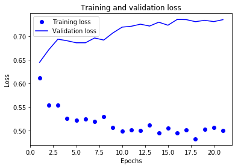

```python
# Plot of the validation and training loss

# "bo" is for "blue dot"
plt.plot(epochs, loss, 'bo', label='Training loss')
# b is for "solid blue line"
plt.plot(epochs, val_loss, 'b', label='Validation loss')
plt.title('Training and validation loss')
plt.xlabel('Epochs')
plt.ylabel('Loss')
plt.legend()

plt.show()
```

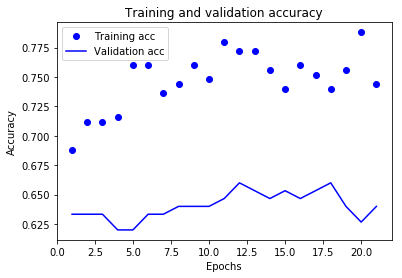

```python
# Plot of the validation and train accuracy

plt.clf()   # clear figure

plt.plot(epochs, acc, 'bo', label='Training acc')
plt.plot(epochs, val_acc, 'b', label='Validation acc')
plt.title('Training and validation accuracy')
plt.xlabel('Epochs')
plt.ylabel('Accuracy')
plt.legend()

plt.show()
```

#### Process followed to design and improve the model

The process I followed to improve and design the model was:

1. Followed the process that we reviewed in class of the example 2 of Neural Networks and the notebook from last class (february 18)
2. Use normalization of data where one-hot-encoding, mean and standard deviation are the key
3. Defined a model of network with 3 layers and 2 dropouts (using relu and softmax for activation)
4. Defined adam to be the optimizer as that was the recommendation in class
5. Tried different combinations of epochs, neurons and layers until the accuracy overcomed 85% (but it couldn't)